# Test a Perceptual Phenomenon

### Analyzing the Stroop Effect

In a Stroop task, participants are presented with a list of words, with each word displayed in a color of ink. The participant’s task is to say out loud the color of the ink in which the word is printed. The task has two conditions: a congruent words condition, and an incongruent words condition. In the congruent words condition, the words being displayed are color words whose names match the colors in which they are printed: for example RED, BLUE. In the incongruent words condition, the words displayed are color words whose names do not match the colors in which they are printed: for example PURPLE, ORANGE. In each case, we measure the time it takes to name the ink colors in equally-sized lists. Each participant will go through and record a time from each condition.

(1) What is the independent variable? What is the dependent variable?

The two main variables in an experiment are the independent and dependent variable.

An independent variable is the variable that is changed or controlled in a scientific experiment to test the effects on the dependent variable.If the independent variable is changed, then an effect is seen in the dependent variable.

The given dataset contains both independent and dependent variable. In this experiment the dependent variable is **the response time of each participant to name the color of the ink.** The independent variable is **congruency condition including congruent words condition and incongruent words condition.**

(2) What is an appropriate set of hypotheses for this task? Specify your null and alternative hypotheses, and clearly define any notation used. Justify your choices.

I chose the two-tailed t-test for given dataset.The dependent T-test compares the mean of the two paired group to see if the statistically significant deferences between these means.The same subjects were tested for congruent and incongruent words.By using the same subjects to test two different conditions,we eliminate the individual differences that occur between the subjects.

**Reasons for selecting The Two-Tailed T-Test**

We don't have any information about the population, we have just 24 sample datasets.

The ability to compare the means of the dataset for the pre and post test validates the benefit of this test selection.

We don't have direction of the test so we choose two tailed test.

**Assumptions**

The distributions of differences in dependent variable between the two related groups should be approximately normally distributed. Normal distributions are symmetric around the center(mean) and follow a ‘bell- shaped’ distribution.

The observations are independent of each another.

The dependent variable should be measured on continuous scale.The dependent t-test requires the sample data to be numeric and continuous, as it is based on the normal distribution.

There should be no significant outliers in the differences between the two related groups. Outliers are simply single data points within your data that do not follow the usual pattern.

**Null Hypothesis** A null hypothesis is a statistical hypothesis in which there is no significant difference exist between the set of variables. It is the original or default statement, with no effect, often represented by H0 (H-zero). In this experiment the null hypothesis is that there is no significant difference exist between the time taken to say the congruent words and incongruent words, means the Mean (xbar) of the Reaction time for the congruent sample will be equal to the mean(xbar) of the reaction time for the incongruent sample.

**$ H_0 $ ( Null Hypothesis ) : (Population Mean)incongruent = (Population Mean)congruent OR $ \mu_i = \mu_c $**

**Alternative Hypothesis** A alternative hypothesis is a statistical hypothesis in which there is no significant difference exist between the set of variables. Often denoted by H1 (H-one).In this experiment the alternative hypothesis is that there is significant difference exist between the time taken to say the congruent words and incongruent words, means the Mean (xbar) of the Reaction time for the congruent sample will not be equal to the mean(xbar) of the reaction time for the incongruent sample.

**$ H_1 $ ( Alternative Hypothesis ) : (Population Mean)incongruent ≠ (Population Mean)congruent OR $ \mu_i$ ≠ $\mu_c $**

**Notations**

Where $ \mu_i$ = Mean time taken to name the ink color for incongruent words.

$ \mu_c$ = Mean time taken to name the ink color for congruent words.

(3) Report some descriptive statistics regarding this dataset. Include at least one measure of central tendency and at least one measure of variability. The name of the data file is 'stroopdata.csv'.

```python
# Perform the analysis here
#importing the Required
from math import *
import seaborn as sns
import numpy as np
import pandas as pd
from scipy.stats import t as pt
import matplotlib.pyplot as plt
%matplotlib inline
```

```python
#import all the data from the csv file and print all
stroop = pd.read_csv("stroopdata.csv")
stroop
```

|  | Congruent | Incongruent |
| --- | --- | --- |
| 0 | 12.079 | 19.278 |
| 1 | 16.791 | 18.741 |
| 2 | 9.564 | 21.214 |
| 3 | 8.630 | 15.687 |
| 4 | 14.669 | 22.803 |
| 5 | 12.238 | 20.878 |
| 6 | 14.692 | 24.572 |
| 7 | 8.987 | 17.394 |
| 8 | 9.401 | 20.762 |
| 9 | 14.480 | 26.282 |
| 10 | 22.328 | 24.524 |
| 11 | 15.298 | 18.644 |
| 12 | 15.073 | 17.510 |
| 13 | 16.929 | 20.330 |
| 14 | 18.200 | 35.255 |
| 15 | 12.130 | 22.158 |
| 16 | 18.495 | 25.139 |
| 17 | 10.639 | 20.429 |
| 18 | 11.344 | 17.425 |
| 19 | 12.369 | 34.288 |
| 20 | 12.944 | 23.894 |
| 21 | 14.233 | 17.960 |
| 22 | 19.710 | 22.058 |
| 23 | 16.004 | 21.157 |

```python
#Find the mean,Median and standard deviation for congruent and incongruent
#Find the mean
c_mean=stroop['Congruent'].mean()
ic_mean=stroop['Incongruent'].mean()
#Find the median
c_median=stroop['Congruent'].median()
ic_median=stroop['Incongruent'].median()
#Find the Standard Deviation
c_stddev=stroop['Congruent'].std()
ic_stddev=stroop['Incongruent'].std()
#print mean,median and standard deviation in a table
tbl=[[int(24),int(24)],[c_mean,ic_mean],[c_median,ic_median],[c_stddev,ic_stddev]]
tbl_df=pd.DataFrame(tbl,index=['Sample Size','Mean','Median','Standard Deviation'],columns=['Congruent','InCongruent'])
tbl_df
```

|  | Congruent | InCongruent |
| --- | --- | --- |
| Sample Size | 24.000000 | 24.000000 |
| Mean | 14.051125 | 22.015917 |
| Median | 14.356500 | 21.017500 |
| Standard Deviation | 3.559358 | 4.797057 |

```python
tbl_df.describe()
```

|  | Congruent | InCongruent |
| --- | --- | --- |
| count | 4.000000 | 4.000000 |
| mean | 13.991746 | 17.957618 |
| std | 8.349380 | 8.860839 |
| min | 3.559358 | 4.797057 |
| 25% | 11.428183 | 16.962389 |
| 50% | 14.203812 | 21.516708 |
| 75% | 16.767375 | 22.511937 |
| max | 24.000000 | 24.000000 |

(4) Provide one or two visualizations that show the distribution of the sample data. Write one or two sentences noting what you observe about the plot or plots.

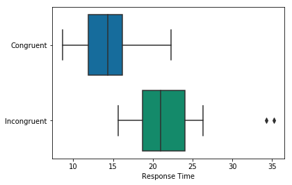

```python
# Build the visualizations here
sns.boxplot(data=stroop[['Congruent','Incongruent']],orient='h',palette='colorblind');
plt.xlabel('Response Time');
```

**Observations:**

The Box-Plot clearly shows difference between the median of two datasets.